# BST260 Group Project – Evaluation of FDNY Emergency Responses

Bryan Nelson, Daniel Shinnick, Carol Wei

December 14, 2019

###INTRODUCTION

**Overview and Motivation:** New York City keeps meticulous, publicly available data. We found the EMS Incident Dispatch data when looking at some of the New York City public datasets, and it seemed like it had great potential for data visualization. This data was generated by New York City’s EMS Computer Aided Dispatch System and provides information about emergency incidents and the Fire Department’s response time.

**Related Work:** We were inspired to work on a data science project with a social impact. In this project, we wanted to build upon the data visualization tools we learned in class. For example, we had created heat maps using vaccination data and built Shiny apps using the Gapminder dataset.

**Initial Questions:** We started off the project wanting to predict emergency response time (demographics, proximity to police station, general neighborhood crime rates, weather, traffic, etc.).

Over the course of the project, we narrowed down our scope and wanted to answer the following questions: Are there any trends in incident response time? Is incident response time related to income level? Does the average incident response time differ across zip codes? Can we predict incident response time?

**Benefits of the project:** By analyzing emergency response time data, we hope to highlight any gaps in coverage and identify areas for improvement from a public policy perspective.

###METHODS

**What Data?**

[EMS Incident Dispatch Data from NYC OpenData](https://data.cityofnewyork.us/Public-Safety/EMS-Incident-Dispatch-Data/76xm-jjuj)

[NYC Income Data by Zip Code from Census Reporter](https://censusreporter.org/data/table/?table=B19013&geo_ids=16000US3651000,860%7C16000US3651000&primary_geo_id=16000US3651000)

**Design Overview:**

*1)* We used R to explore the data, presenting frequencies of event types, distributions of response times (stratified by regions of the city), summarizing demographics, etc.

*2)* We created an incident response time heat map in a Shiny app.

*3)* We created a tree-based model to predict incident response time.

###R CODE AND ANALYSIS

```r
####load necessary libraries
#libraries for data manipulation
library(tidyverse)
library(lubridate)

#libraries for heat map
library(shiny)
library(tigris)
library(dplyr)
library(leaflet)
library(sp)
library(ggmap)
library(maptools)
library(broom)
library(httr)
library(rgdal)
library(plotrix)
library(lsr)

#libraries for decision tree
library(rsample)    # data splitting
library(rpart)      # performing regression trees
library(rpart.plot) # plotting regression trees
library(randomForest) # random forest

set.seed(1022) #set seed for reproducibility

#NOTE: set working directory when re-producing this output on your own machine.
#setwd("/Users/bryannelson/Google Drive/HSPH/bst260/final group project")
```

```r
#NOTE: remove "eval=FALSE" when re-producing this output on your own machine. After the initial derived dataset creation, we have set eval=FALSE to conserve processing time and system memory.

#read raw data files
ems <- read.csv("EMS_Incident_Dispatch_Data.csv", header=T)
income <- read.csv("acs2017_5yr_B19013_16000US3663979.csv", header=T)

#get what variables are in the dataset
colnames(ems) <- tolower(colnames(ems))
#restrict to NYC with nonmissing incidence rate data
ems <- ems %>% filter(cad_incident_id >= '183350001' & !is.na(incident_response_seconds_qy))
#Note that incident_response_seconds_qy is the sum of dispatch_response_seconds_qy and incident_travel_tm_seconds_qy

#get census income data
income <- income %>% slice(1196:1435)
income$name <- as.numeric(levels(income$name))[income$name]
income$name <- as.integer(income$name)
names(income)[names(income) == 'name'] <- 'zipcode'
names(income)[names(income) == 'B19013001'] <- 'median_income'
income <- income %>% select(zipcode, median_income)

#combine the EMS and Income data by zipcode
ems2 <- left_join(ems, income, by = "zipcode")

#want to separate out the indicent date to create weekday and hour variables
ems2$incident_datetime <- as.character(ems2$incident_datetime)
ems2$incident_datetime <- mdy_hms(ems2$incident_datetime)
ems2$weekday <- wday(ems2$incident_datetime)
ems2$hour<- hour(ems2$incident_datetime)

#rename income
names(ems2)[names(ems2) == 'median_income'] <- 'income'

#create the smaller permanent.csv file to work with.
write.csv(ems2, "ems_incident_dispatch_data_v2.csv", row.names=FALSE)
```

The following code was used for data exploration. *A priori*, we were interested in income, borough, incident severity, day, and time of day as predictors of response time. One consideration we made when choosing to use Borough is that zip code, congressional district, police precinct, school district, etc. could all be collinear. They also could not be included in a regression model with borough because there’s only one borough per zip code.

```r
#load the smaller December 2018 data
emsdata <- read.csv("ems_incident_dispatch_data_v2.csv", header=T)

#what variables do we have to work with?
names(emsdata)
```

```
##  [1] "cad_incident_id"                "incident_datetime"
##  [3] "initial_call_type"              "initial_severity_level_code"
##  [5] "final_call_type"                "final_severity_level_code"
##  [7] "first_assignment_datetime"      "valid_dispatch_rspns_time_indc"
##  [9] "dispatch_response_seconds_qy"   "first_activation_datetime"
## [11] "first_on_scene_datetime"        "valid_incident_rspns_time_indc"
## [13] "incident_response_seconds_qy"   "incident_travel_tm_seconds_qy"
## [15] "first_to_hosp_datetime"         "first_hosp_arrival_datetime"
## [17] "incident_close_datetime"        "held_indicator"
## [19] "incident_disposition_code"      "borough"
## [21] "incident_dispatch_area"         "zipcode"
## [23] "policeprecinct"                 "citycouncildistrict"
## [25] "communitydistrict"              "communityschooldistrict"
## [27] "congressionaldistrict"          "reopen_indicator"
## [29] "special_event_indicator"        "standby_indicator"
## [31] "transfer_indicator"             "income"
## [33] "weekday"                        "hour"
```

```r
#ems response time is in seconds, but it would be more interpretable in minutes, so create that variable
emsdata<-emsdata %>% mutate(responsemins=incident_response_seconds_qy/60)
emsdata<-emsdata %>% mutate(weekday=as.factor(weekday))

#make sure response time is non-zero
emsdata <-emsdata %>% filter(responsemins > 0)

#look at the distribution of response times in minutes, income, and hour
summary(emsdata$responsemins)
```

```
##     Min.  1st Qu.   Median     Mean  3rd Qu.     Max.
##   0.0167   5.5167   7.8500  10.6050  11.6333 532.3833
```

```r
#look at extremely high outliers (let's try 3+ hours)
rspoutliers<-emsdata %>% filter(responsemins > 180)
rspoutliers$responsemins
```

```
##  [1] 231.7667 324.8000 291.2333 291.5167 315.6500 490.8167 461.7333
##  [8] 306.1667 448.4167 180.5000 418.1500 532.3833 283.3500 318.2500
## [15] 336.2667 428.0000 297.1667 299.8000 391.9500 213.5500 449.1000
## [22] 418.9833 299.0833 294.9333 301.7500 459.4833 460.6000 261.9833
## [29] 394.0167 279.6000 202.4000 265.5667 261.9000 187.2667 421.4333
## [36] 198.7833 416.8667 426.5333 254.8500 415.1333 336.4333 253.9333
## [43] 311.8500 387.9333 243.5500 218.0667 531.1500 409.3500 416.4167
## [50] 408.8333 227.3167 428.2500 200.5500 185.7333 413.1333 295.3333
## [57] 360.1000 391.6167
```

```r
summary(emsdata$initial_severity_level_code)
```

```
##    Min. 1st Qu.  Median    Mean 3rd Qu.    Max.
##   1.000   3.000   4.000   4.176   6.000   8.000
```

```r
summary(emsdata$income)
```

```
##    Min. 1st Qu.  Median    Mean 3rd Qu.    Max.    NA's
##       0   35449   51269   58162   72874  250001    1734
```

```r
summary(emsdata$hour)
```

```
##    Min. 1st Qu.  Median    Mean 3rd Qu.    Max.
##    0.00    8.00   13.00   12.75   18.00   23.00
```

```r
#look at summary of initial severity level (higher indicates less severe), borough, and weekday
ftable(emsdata$initial_severity_level_code)
```

```
##      1     2     3     4     5     6     7     8
##
##   1663 26759 16918 24445 19044 19440 12634   214
```

```r
ftable(emsdata$borough)
```

```
##  BRONX BROOKLYN MANHATTAN QUEENS RICHMOND / STATEN ISLAND
##
##  28230    33641     30508  23508                     5230
```

```r
ftable(emsdata$weekday)
```

```
##      1     2     3     4     5     6     7
##
##  18279 19823 15222 15834 15701 16751 19507
```

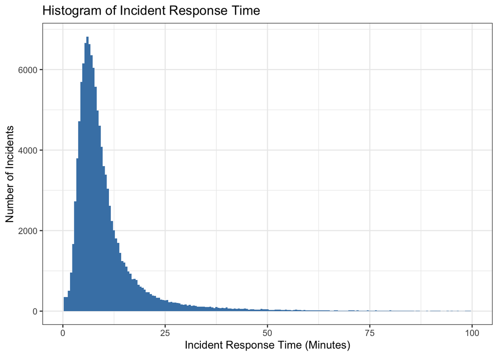

```r
#plot distribution of response time, first univariably, then stratified by our covariates of interest
emsdata %>%
  ggplot(aes(responsemins)) +
  geom_histogram(binwidth = .5, fill='steelblue') +
  xlim(0, 100) +
  theme_bw() +
  #add descriptive labels
  xlab("Incident Response Time (Minutes)") +
  ylab("Number of Incidents") +
  ggtitle("Histogram of Incident Response Time")
```

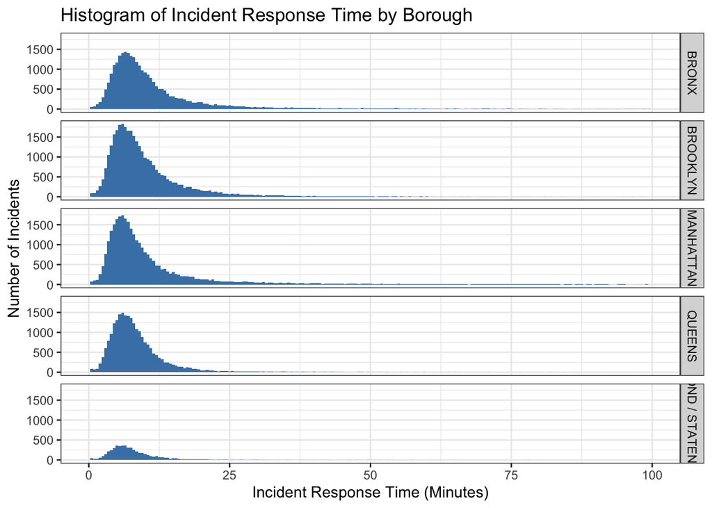

```r
emsdata %>%
  ggplot(aes(responsemins)) +
  geom_histogram(binwidth = .5, fill='steelblue') +
  xlim(0,100) +
  facet_grid(borough~.) +
  theme_bw() +
  #add descriptive labels
  xlab("Incident Response Time (Minutes)") +
  ylab("Number of Incidents") +
  ggtitle("Histogram of Incident Response Time by Borough")
```

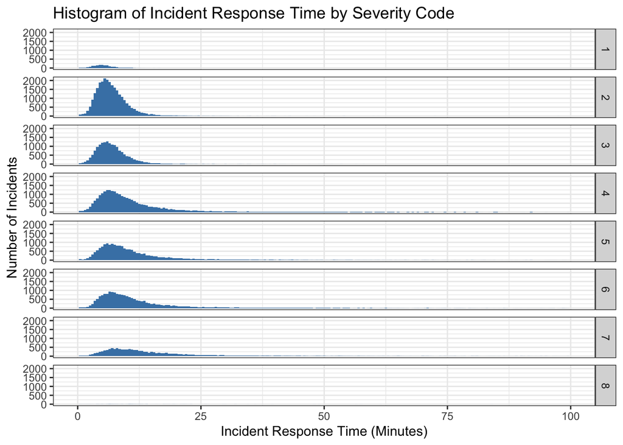

```r
emsdata %>%
  ggplot(aes(responsemins)) +
  geom_histogram(binwidth = .5, fill = 'steelblue') +
  xlim(0,100) +
  facet_grid(initial_severity_level_code~.) +
  theme_bw()+
  #add descriptive labels
  xlab("Incident Response Time (Minutes)") +
  ylab("Number of Incidents") +
  ggtitle("Histogram of Incident Response Time by Severity Code")
```

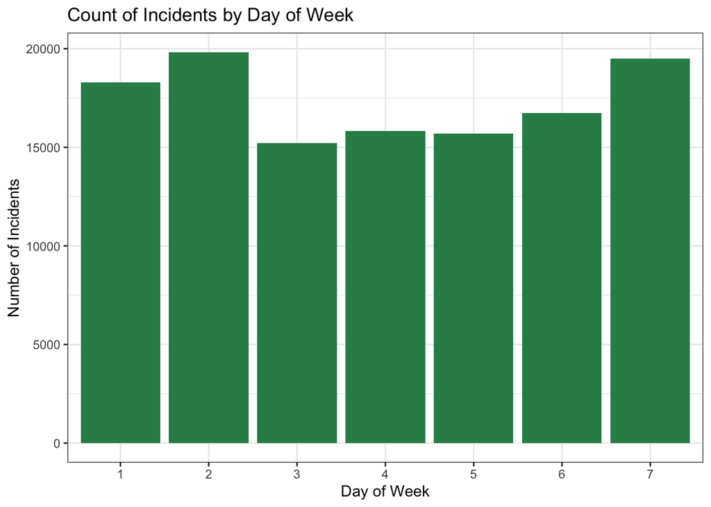

```r
#Look at our covariates of interest
#Incidents by day of week, hour, severity code
emsdata %>%
  ggplot(aes(weekday)) +
  geom_bar(fill='seagreen') +
  theme_bw()+
  #add descriptive labels
  xlab("Day of Week") +
  ylab("Number of Incidents") +
  ggtitle("Count of Incidents by Day of Week")
```

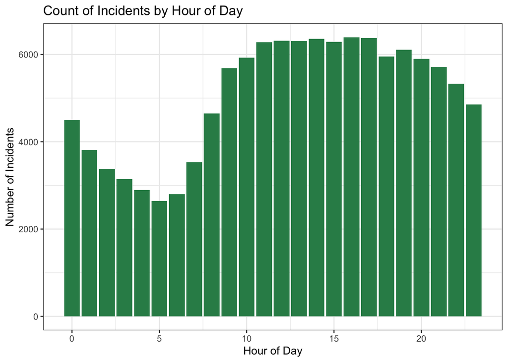

```r
emsdata %>%
  ggplot(aes(hour)) +
  geom_bar(fill='seagreen') +
  theme_bw() +
  #add descriptive labels
  xlab("Hour of Day") +
  ylab("Number of Incidents") +
  ggtitle("Count of Incidents by Hour of Day")
```

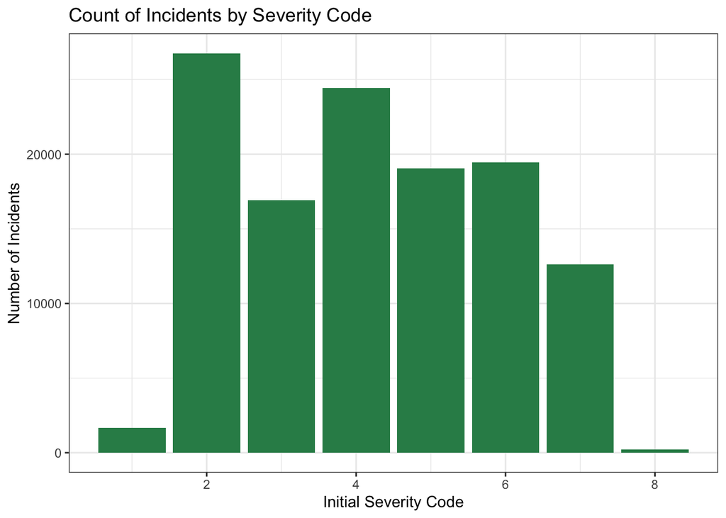

```r
emsdata %>%
  ggplot(aes(initial_severity_level_code)) +
  geom_bar(fill='seagreen') +
  theme_bw()+
  #add descriptive labels
  xlab("Initial Severity Code") +
  ylab("Number of Incidents") +
  ggtitle("Count of Incidents by Severity Code")
```

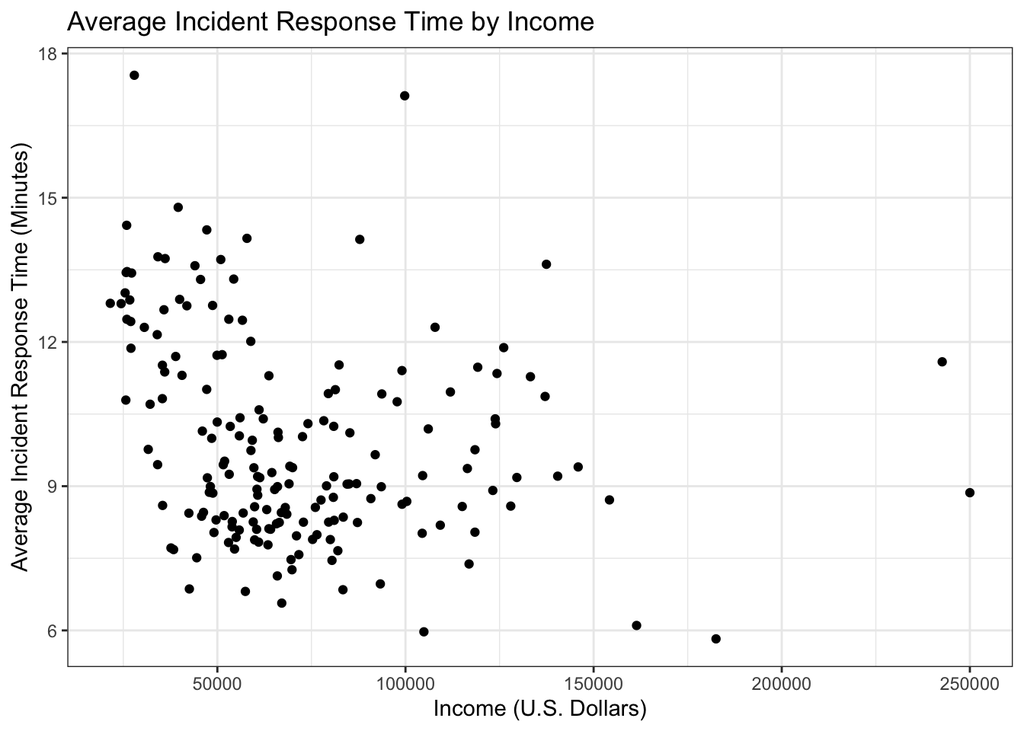

```r
#avg response time vs. income
emsdata %>%
  group_by(income) %>%
  filter (income != 0) %>%
  summarize(avg_responsetime = mean(responsemins)) %>%
  ggplot(aes(income, avg_responsetime)) +
  geom_point() +
  theme_bw()+
  #add descriptive labels
  xlab("Income (U.S. Dollars)") +
  ylab("Average Incident Response Time (Minutes)") +
  ggtitle("Average Incident Response Time by Income")
```

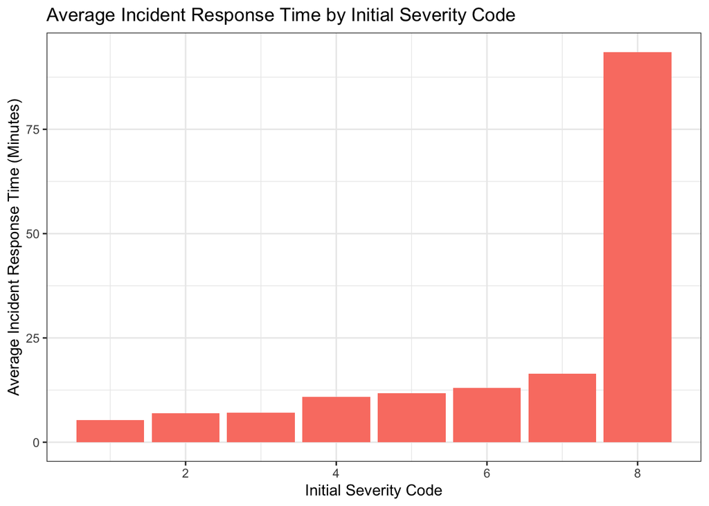

```r
#avg response time by initial severity level code
emsdata %>%
  group_by(initial_severity_level_code) %>%
  filter(!is.na(initial_severity_level_code)) %>%
  summarize(avg_responsetime = mean(responsemins)) %>%
  ggplot(aes(initial_severity_level_code, avg_responsetime)) +
  geom_bar(stat='identity', fill="salmon") +
  theme_bw()+
  #add descriptive labels
  xlab("Initial Severity Code") +
  ylab("Average Incident Response Time (Minutes)") +
  ggtitle("Average Incident Response Time by Initial Severity Code")
```

The following code was used to create the heat map of EMS response times (unadjusted) by NYC zip code. Please note that this code is run in the Shiny app, and is not compiled below.

```r
# Read in data and cut outliers
dat <- read.csv("ems_incident_dispatch_data_v2.csv", header=T)
dat <- dat[which(dat$dispatch_response_seconds_qy > 0),]
dat <- dat[which(dat$initial_severity_level_code < 8),]

# Use google maps to get nyc map
register_google(key = 'AIzaSyCRpZB738AZsCoBkgMOKkGT6IORiP10dc0')
nyc_map <- get_map(location = c(lon = -74.00, lat = 40.71), maptype = "terrain", zoom = 11)
# Find zip codes in our dataset
zips <- unique(dat$zipcode)
zips <- as.vector(zips)

options(tigris_use_cache = TRUE)
nyc <- zctas(cb = TRUE, starts_with = zips)

# Sort Data
v <- dat %>%
  group_by(zipcode, initial_severity_level_code) %>%
  summarize(avg = mean(incident_response_seconds_qy, na.rm = TRUE), income=mean(income, na.rm=TRUE))

v1 <- dat %>%
  group_by(zipcode) %>%
  summarize(avg = mean(incident_response_seconds_qy, na.rm = TRUE), income=mean(income, na.rm=TRUE))

# Color scheme of average response time. v1 used for consistency
rbPal <- colorRampPalette(c('white','red3'))
v$Col <- rbPal(6)[as.numeric(cut(v$avg,breaks = c(0,as.vector(as.numeric(quantile(v1$avg,probs = c(1/6,2/6,3/6,4/6,5/6)))),100000)))]

# Sorting Data
t <- getSpPPolygonsIDSlots(nyc)
zipcodes <- nyc$GEOID10

values <- data.frame("id" = t, "ZIPCODE" = zipcodes, stringsAsFactors = FALSE)
values <- merge(x=v, y=values, by.x='zipcode', by.y='ZIPCODE')

options(warn=-1)
tidy_nyc = tidy(nyc)
plotData = left_join(tidy_nyc, values, by='id')
plotData$x <- plotData$long
plotData$y <- plotData$lat
plotData$minutes <- round(plotData$avg/60, digits = 1)

# Redo for overall average data
rbPal <- colorRampPalette(c('white','red3'))
v1$Col <- rbPal(6)[as.numeric(quantileCut(v1$avg,6),breaks = 6)]

t1 <- getSpPPolygonsIDSlots(nyc)
zipcodes <- nyc$GEOID10

values1 <- data.frame("id" = t1, "ZIPCODE" = zipcodes, stringsAsFactors = FALSE)
values1 <- merge(x=v1, y=values1, by.x='zipcode', by.y='ZIPCODE')

tidy_nyc = tidy(nyc)
plotData1 = left_join(tidy_nyc,values1,by='id')
plotData1$x <- plotData1$long
plotData1$y <- plotData1$lat
plotData1$minutes <- round(plotData1$avg/60, digits = 1)

# Used to create legend
cuts <- round(as.numeric(quantile(v1$avg,probs = c(1/6,2/6,3/6,4/6,5/6)))/60, digits = 1)
cuts0 <- paste('0 - ' , cuts[1], sep = '')
cuts1 <- paste(cuts[1], ' - ' , cuts[2], sep = '')
cuts2 <- paste(cuts[2], ' - ' , cuts[3], sep = '')
cuts3 <- paste(cuts[3], ' - ' , cuts[4], sep = '')
cuts4 <- paste(cuts[4], ' - ' , cuts[5], sep = '')
cuts5 <- paste(cuts[5], '+', sep = '')
cuts <- c(cuts0,cuts1,cuts2,cuts3,cuts4,cuts5)

timesY <- 40.7580
timesX <- 73.9855

#pythagorean distance
plotData$distance <- (sqrt((plotData$x+timesX)^2 + (plotData$y-timesY)^2))

highPriority <- plotData[which(plotData$initial_severity_level_code < 4),]
emergency <- plotData[which(plotData$initial_severity_level_code ==1),]

####### Regression
distMod <- lm(avg ~ distance, data = highPriority)
distMod2 <- lm(avg ~ distance, data = emergency)

summary(distMod)
```

```
##
## Call:
## lm(formula = avg ~ distance, data = highPriority)
##
## Residuals:
##     Min      1Q  Median      3Q     Max
## -234.97  -50.91    0.55   46.17  735.06
##
## Coefficients:
##             Estimate Std. Error t value Pr(>|t|)
## (Intercept)  368.218      1.430  257.51   <2e-16 ***
## distance     188.698      8.632   21.86   <2e-16 ***
## ---
## Signif. codes:  0 '***' 0.001 '**' 0.01 '*' 0.05 '.' 0.1 ' ' 1
##
## Residual standard error: 87.3 on 17649 degrees of freedom
## Multiple R-squared:  0.02636,    Adjusted R-squared:  0.02631
## F-statistic: 477.9 on 1 and 17649 DF,  p-value: < 2.2e-16
```

```r
summary(distMod2)
```

```
##
## Call:
## lm(formula = avg ~ distance, data = emergency)
##
## Residuals:
##      Min       1Q   Median       3Q      Max
## -164.597  -35.623   -1.095   32.980  290.029
##
## Coefficients:
##             Estimate Std. Error t value Pr(>|t|)
## (Intercept)  283.995      1.753  161.96   <2e-16 ***
## distance     248.449     10.719   23.18   <2e-16 ***
## ---
## Signif. codes:  0 '***' 0.001 '**' 0.01 '*' 0.05 '.' 0.1 ' ' 1
##
## Residual standard error: 60.03 on 5598 degrees of freedom
## Multiple R-squared:  0.08757,    Adjusted R-squared:  0.08741
## F-statistic: 537.3 on 1 and 5598 DF,  p-value: < 2.2e-16
```

```r
# Shiny App UI/Server
ui = fluidPage(
  theme = shinythemes::shinytheme("darkly"),
  titlePanel("New York City EMS Response Time Heat Map"),

  tabsetPanel(

    tabPanel("Average Response Time",
             sidebarLayout(
               sidebarPanel(
                 p(em("Response time"), "mapped by average within zipcode"),
                 br(),
                 p(em("Click map"), "to see average income and average EMS response time for a certain zip code."),
                 br(),
                 plotOutput("Legend", height = '150px')

               ),

               mainPanel(
                 plotOutput("Map1",
                            click = "plot2_click")
               )
             ),
             fluidRow(
               column(width = 12,
                      h4("Points near click"),
                      verbatimTextOutput("click_info1")
               )
             )
    ),

    tabPanel("Severity Selection",
             sidebarLayout(
               sidebarPanel(
                 p(em("Response Time"), "mapped by severity code assessed at call. More emergent situations are given severity scores of 1, and thus generally have faster response times"),

                 br(),

                 p(em("Click map"), "to see average income and average EMS response time for a certain zip code and severity code."),

                 selectInput("severity", label = "Select call severity:",
                             choices = (as.list(sort(unique(dat$initial_severity_level_code))))),
                 br(),
                 plotOutput("Legend1", height = '150px')

               ),

               mainPanel(
                 plotOutput("Map",
                            click = "plot1_click")
               )
             ),

             fluidRow(
               column(width = 12,
                      h4("Points near click"),
                      verbatimTextOutput("click_info")
               )
             )
    )
  )
)

server = function(input, output) {

  output$Map = renderPlot({

    gg <- ggmap(nyc_map)
    gg +
      geom_polygon(data=plotData %>% filter(initial_severity_level_code %in% input$severity), aes(x=long, y=lat, group=group), color="blue", fill = plotData %>% filter(initial_severity_level_code %in% input$severity) %>% .$Col, alpha=0.5) +
      ggthemes::theme_map()
  }
  )

  output$click_info <- renderPrint({
    nearPoints(plotData %>% filter(initial_severity_level_code %in% input$severity) %>% select(x, y, zipcode, income, minutes), input$plot1_click, 'x', 'y', maxpoints = 1, threshold = 20, addDist = FALSE)
  })

  output$Map1 = renderPlot({

    gg <- ggmap(nyc_map)
    gg +
      geom_polygon(data=plotData1, aes(x=long, y=lat, group=group), color="blue", fill = plotData1$Col, alpha=0.5) +
      ggthemes::theme_map()
  }
  )

  output$click_info1 <- renderPrint({
    nearPoints(plotData1 %>% select(x, y, zipcode, income, minutes), input$plot2_click, 'x', 'y', maxpoints = 1, threshold = 20, addDist = FALSE)
  })

  output$Legend <- renderPlot({
    par(bg = 'light grey')
    plot(NULL ,xaxt='n',yaxt='n',bty='n',ylab='',xlab='', xlim=0:1, ylim=0:1)
    legend("topleft", legend = cuts, title = 'Mean Response Minutes', pch=16, xpd = TRUE, inset = c(-.2,-3.1), pt.cex=3, cex=1.2, bty='n',
           col=rbPal(6))
  })

  output$Legend1 <- renderPlot({
    par(bg = 'light grey')
    plot(NULL ,xaxt='n',yaxt='n',bty='n',ylab='',xlab='', xlim=0:1, ylim=0:1)
    legend("topleft", legend = cuts, title = 'Mean Response Minutes', pch=16, xpd = TRUE, inset = c(-.2,-3.1), pt.cex=3, cex=1.2, bty='n',
           col=rbPal(6))
  })

}

# Run the application
#shinyApp(ui = ui, server = server)
```

The following code was used to develop and evaluate the decision tree to predict EMS response time:

```r
# we are interested in creating a regression decision tree of response time predicted by initial severity, income, borough, weekday, and time of day.

#in order to grow the tree and test the tree, we need to separate our data into training and testing datasets
#create training (70%) and test (30%) sets for ems data
ems_split <- initial_split(emsdata, prop=0.7)
ems_train <- training(ems_split)
ems_test  <- testing(ems_split)

#Heather suggested two different approaches, 1) decision tree 2) random forest
###1) Decision Tree
#grow regression based decision tree using training data and the a priori variables of interest.
fit <- rpart(responsemins ~ initial_severity_level_code + income + borough + weekday + hour, method="anova", data=ems_train)

#print the decision tree and the plot of the tree
summary(fit)
```

```
## Call:
## rpart(formula = responsemins ~ initial_severity_level_code +
##     income + borough + weekday + hour, data = ems_train, method = "anova")
##   n= 84782
##
##           CP nsplit rel error    xerror       xstd
## 1 0.13372108      0 1.0000000 1.0000407 0.06757495
## 2 0.04608862      2 0.7325578 0.7383294 0.02729008
## 3 0.02201423      3 0.6864692 0.6922517 0.02694394
## 4 0.01330246      5 0.6424408 0.6833292 0.02923423
## 5 0.01000000      6 0.6291383 0.6775802 0.03146952
##
## Variable importance
##                        hour initial_severity_level_code
##                          46                          36
##                     borough                      income
##                          10                           7
##                     weekday
##                           1
##
## Node number 1: 84782 observations,    complexity param=0.1337211
##   mean=10.64378, MSE=160.5513
##   left son=2 (84623 obs) right son=3 (159 obs)
##   Primary splits:
##       initial_severity_level_code < 7.5   to the left,  improve=0.090325590, (0 missing)
##       income                      < 42162 to the right, improve=0.009262829, (1219 missing)
##       borough                     splits as  RLRLL,     improve=0.007944012, (0 missing)
##       hour                        < 12.5  to the left,  improve=0.002859821, (0 missing)
##       weekday                     splits as  LRRRRRR,   improve=0.002233200, (0 missing)
##
## Node number 2: 84623 observations,    complexity param=0.04608862
##   mean=10.47871, MSE=100.9757
##   left son=4 (31602 obs) right son=5 (53021 obs)
##   Primary splits:
##       initial_severity_level_code < 3.5   to the left,  improve=0.073418540, (0 missing)
##       income                      < 42162 to the right, improve=0.014230530, (1203 missing)
##       borough                     splits as  RLRLL,     improve=0.013252560, (0 missing)
##       hour                        < 11.5  to the left,  improve=0.007280077, (0 missing)
##       weekday                     splits as  LRLLLRL,   improve=0.003504082, (0 missing)
##
```

[output cut: 50 more lines]

```
##       weekday splits as  LRLRLRL,   improve=0.10550600, (0 missing)
##       borough splits as  LLR--,     improve=0.08581648, (0 missing)
##       hour    < 0.5   to the right, improve=0.03695670, (0 missing)
##   Surrogate splits:
##       borough splits as  LLR--,   agree=0.727, adj=0.250, (4 split)
##       weekday splits as  LLRRLLL, agree=0.697, adj=0.167, (0 split)
##
## Node number 15: 14 observations
##   mean=392.275, MSE=6979.994
##
## Node number 28: 22 observations
##   mean=154.4894, MSE=24023.91
##
## Node number 29: 15 observations
##   mean=351.4322, MSE=12207.65
```

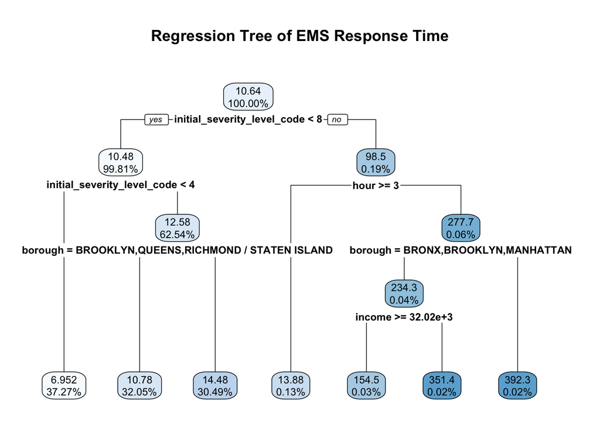

```r
rpart.plot(fit, digits=4, main="Regression Tree of EMS Response Time")
```

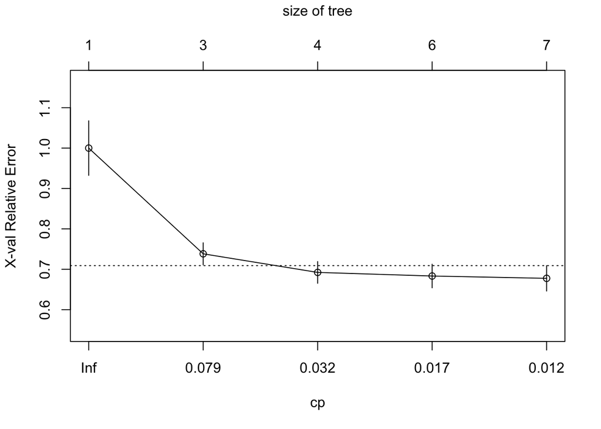

```r
#look at tree size
plotcp(fit)
```

```r
#use the tree for prediction
preds <- predict(fit, ems_test)
test <- ems_test[,"responsemins"]
regtreemse<-mean((preds-test)^2)
regtreemsesq<-sqrt(regtreemse)

print(paste0("The regression tree's mean square error is ", signif(regtreemse,3)))
```

```
## [1] "The regression tree's mean square error is 101"
```

```r
print(paste0("The regression tree's predictions are within ", signif(regtreemsesq,3), " minutes."))
```

```
## [1] "The regression tree's predictions are within 10.1 minutes."
```

```r
#Sensitivity Analysis - let's try the decision tree again but log transform response time given how extreme some of the outliers are..
emslog<- emsdata %>% filter(!is.na(responsemins) & responsemins > 0) %>% mutate(logresp=log10(responsemins))
summary(emslog$logresp)
```

```
##    Min. 1st Qu.  Median    Mean 3rd Qu.    Max.
## -1.7782  0.7417  0.8949  0.9134  1.0657  2.7262
```

```r
#create training (70%) and test (30%) sets for ems data (log transformed)
emslog_split <- initial_split(emslog, prop=0.7)
emslog_train <- training(emslog_split)
emslog_test  <- testing(emslog_split)

#grow regression based decision tree using training data and the a priori variables of interest.
fitlog <- rpart(logresp ~ initial_severity_level_code + income + borough + weekday + hour, method="anova", data=emslog_train)

fitlog
```

```
## n= 84782
##
## node), split, n, deviance, yval
##       * denotes terminal node
##
##  1) root 84782 7406.3800 0.9135865
##    2) initial_severity_level_code< 3.5 31718 1505.3570 0.7939587 *
##    3) initial_severity_level_code>=3.5 53064 5175.7970 0.9850917
##      6) income>=42162 34505 3145.6750 0.9468191
##       12) initial_severity_level_code< 6.5 28614 2392.6140 0.9227662 *
##       13) initial_severity_level_code>=6.5 5891  656.0986 1.0636500 *
##      7) income< 42162 18559 1885.6100 1.0562480 *
```

```r
#print the decision tree and the plot of the tree
summary(fitlog)
```

```
## Call:
## rpart(formula = logresp ~ initial_severity_level_code + income +
##     borough + weekday + hour, data = emslog_train, method = "anova")
##   n= 84782
##
##           CP nsplit rel error    xerror        xstd
## 1 0.09791914      0 1.0000000 1.0000112 0.009761539
## 2 0.01951180      1 0.9020809 0.9020976 0.009588727
## 3 0.01309185      2 0.8825691 0.8826517 0.009529833
## 4 0.01000000      3 0.8694772 0.8695831 0.009446730
##
## Variable importance
## initial_severity_level_code                      income
##                          81                          14
##                     borough
##                           5
##
## Node number 1: 84782 observations,    complexity param=0.09791914
##   mean=0.9135865, MSE=0.08735793
##   left son=2 (31718 obs) right son=3 (53064 obs)
##   Primary splits:
##       initial_severity_level_code < 3.5     to the left,  improve=0.097919140, (0 missing)
##       income                      < 41247   to the right, improve=0.017098340, (1190 missing)
##       borough                     splits as  RRRLL,       improve=0.011020700, (0 missing)
##       hour                        < 12.5    to the left,  improve=0.005551718, (0 missing)
##       weekday                     splits as  LRLRLRL,     improve=0.003073241, (0 missing)
##
## Node number 2: 31718 observations
##   mean=0.7939587, MSE=0.04746065
##
## Node number 3: 53064 observations,    complexity param=0.0195118
##   mean=0.9850917, MSE=0.09753876
##   left son=6 (34505 obs) right son=7 (18559 obs)
##   Primary splits:
##       income                      < 42162   to the right, improve=0.028160820, (876 missing)
##       initial_severity_level_code < 6.5     to the left,  improve=0.025682620, (0 missing)
##       borough                     splits as  RRRLL,       improve=0.024931620, (0 missing)
##       hour                        < 6.5     to the left,  improve=0.009649533, (0 missing)
##       weekday                     splits as  LRLRLRL,     improve=0.004713632, (0 missing)
##   Surrogate splits:
##       borough splits as  RLLLL, agree=0.774, adj=0.361, (876 split)
##
## Node number 6: 34505 observations,    complexity param=0.01309185
##   mean=0.9468191, MSE=0.09116578
##   left son=12 (28614 obs) right son=13 (5891 obs)
##   Primary splits:
##       initial_severity_level_code < 6.5     to the left,  improve=0.030824280, (0 missing)
##       borough                     splits as  RRRLL,       improve=0.015305800, (0 missing)
##       hour                        < 6.5     to the left,  improve=0.012152110, (0 missing)
##       weekday                     splits as  LRRRRRL,     improve=0.005327971, (0 missing)
##       income                      < 43299.5 to the left,  improve=0.003371648, (779 missing)
##
## Node number 7: 18559 observations
##   mean=1.056248, MSE=0.1016008
##
## Node number 12: 28614 observations
##   mean=0.9227662, MSE=0.08361689
##
## Node number 13: 5891 observations
##   mean=1.06365, MSE=0.111373
```

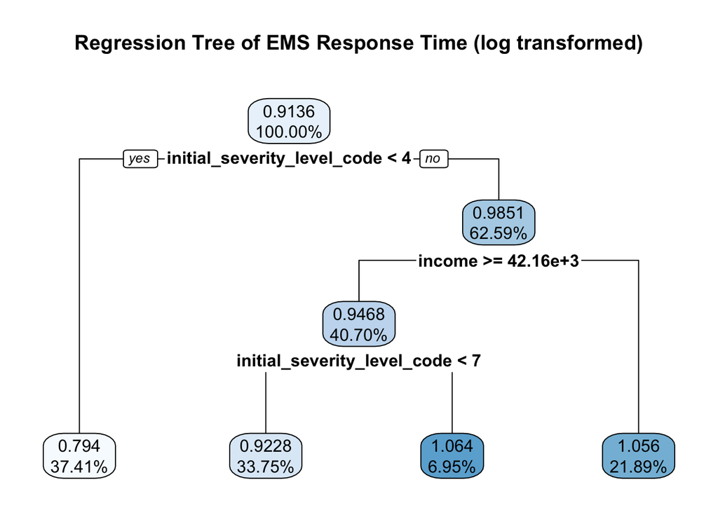

```r
rpart.plot(fitlog, digits=4, main="Regression Tree of EMS Response Time (log transformed)")
```

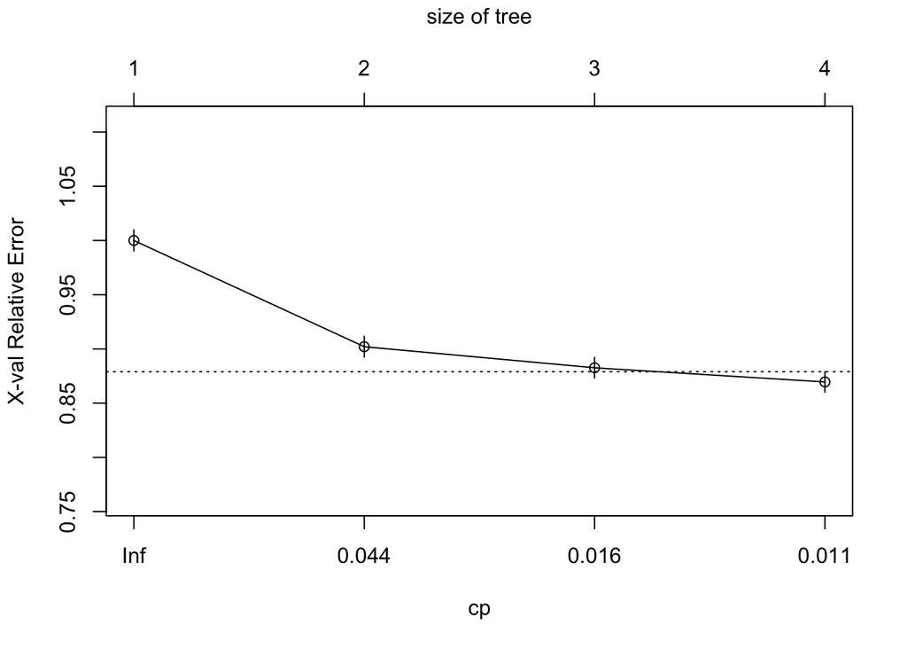

```r
#look at tree size
plotcp(fitlog)
```

```r
#use the tree for prediction
predslog <- predict(fitlog, emslog_test)
testlog <- emslog_test[,"logresp"]
regtreemselog<-mean((predslog-testlog)^2)
regtreemsesqlog<-sqrt(regtreemselog)
regtreeseqlogtrans<-10^regtreemsesqlog

print(paste0("The logged regression tree's mean square error is ", signif(regtreemselog,3)))
```

```
## [1] "The logged regression tree's mean square error is 0.0782"
```

```r
print(paste0("The logged regression tree's predictions are within ", signif(regtreemsesqlog,3), " log_10 minutes (", signif(regtreeseqlogtrans,3), " minutes)."))
```

```
## [1] "The logged regression tree's predictions are within 0.28 log_10 minutes (1.9 minutes)."
```

```r
###2) Random Forest
#compare to random forest
fit2 <- randomForest(responsemins ~ initial_severity_level_code + income + borough + weekday + hour, data=ems_train, na.action = na.omit, ntree=100, importance=TRUE)
print(fit2) # view results
```

```
##
## Call:
##  randomForest(formula = responsemins ~ initial_severity_level_code +      income + borough + weekday + hour, data = ems_train, ntree = 100,      importance = TRUE, na.action = na.omit)
##                Type of random forest: regression
##                      Number of trees: 100
## No. of variables tried at each split: 1
##
##           Mean of squared residuals: 106.8771
##                     % Var explained: 29.75
```

```r
importance(fit2) # importance of each predictor
```

```
##                               %IncMSE IncNodePurity
## initial_severity_level_code 21.060584     1790121.0
## income                      12.616699      484051.0
## borough                     15.796795      295545.6
## weekday                      6.660911      276863.2
## hour                        13.773985      758638.8
```

```r
#filter out missing values from the testing data
ems_test_nona<- ems_test %>% filter(!is.na(responsemins) & !is.na(initial_severity_level_code) & !is.na(income) & !is.na(borough) & !is.na(weekday) & !is.na(hour))

preds2 <- predict(fit2, ems_test_nona)
test2 = ems_test_nona[,"responsemins"]
randmse<-mean((preds2-test2)^2)
randmsesq<-sqrt(randmse)

print(paste0("The random forest's mean square error is ", signif(randmse,3)))
```

```
## [1] "The random forest's mean square error is 90.4"
```

```r
print(paste0("The random forest's predictions are within ", signif(randmsesq,3), " minutes."))
```

```
## [1] "The random forest's predictions are within 9.51 minutes."
```

###RESULTS AND DISCUSSION

Our aim was to explore predictors of emergency response time in NYC using data from December 2018. Of particular interest was income, borough, incident severity, day, and time of the day.

We first examined each variable. NYC’s EMS response time in December 2018 was highly skewed (as one might expect given the differing severities of emergency calls) with a median (Q1, Q3) of 7.9 (5.5, 11.6) minutes but several high outliers above 180 (and as high as 532) minutes. This skewness and general shape remains similar when stratifying by borough or initial severity level.

Generally, event were reported more on the weekend (Saturday, Sunday and Monday), during the afternoon/early evening, and were most commonly of level 2-4, with very few calls at either severity extreme (levels 1 or 8).

There does not appear to be a linear relationship between average EMS response time and income, although there may be two clusters such that higher incomes may have a weak linear relationship but lower incomes do not. There did appear to be a small but steady increase in average EMS response time as severity code increased (so became less severe) for codes 1-7, where EMS response time for code 8 (least severe) was longer than for any other severity code by an order of magnitude. We did not regress or check this correlation as our intention was to descriptively assess the variables we were interested in *a priori*.

We created a heat map in a Shiny app to display the average incident response time by zip code. Darker areas represent higher response times. We added plot interaction to see average income and average response time for a selected zip code. In addition, we mapped by severity code assessed at call. More emergent situations are given severity scores of 1, and thus generally have faster response times. On our severity selection page, we can see that zip codes further from downtown generally have longer response times for severity 2-3 calls. We confirmed this result with a simple linear regression with Pythagorean distance from Times Square as our covariate and average response time within zip code for severity 1-3 as our outcome. For each mile a zip code was from Times Square, our model predicted a 2.7 second increase in average response time for high priority calls.

Our main analysis was using tree-based models to predict EMS response times. To accomplish this we performed 1) a regression tree and 2) a random forest. For each model we split into training (70%) and testing (30%) datasets randomly. EMS response time in minutes, initial severity level, income, and hour of day were analyzed continuously, while borough and weekday were treated categorically.

In the first regression tree, we found that initial severity code was important, as was time of day and borough. On average, individuals with less severe emergencies in the middle of the night outside of Bronx, Brooklyn, and Manhattan had the longest wait time for EMS responders (392 minutes). The regression based tree generated predictions within 10.1 minutes of the actual observed response time. This is relatively poor performance considering the average EMS response time in our data was 10.6 minutes. Generally, we were surprised to see how short the majority of response times were.

Because of the skewness of EMS response times, we performed a sensitivity analysis to create a regression tree on log_10(EMS response time). This greatly improved the model’s predictions - the predictions were within 1.9 minutes of the actual observed response time.

For more accurate predictions, we would need more information such as specific location of calls, which were not provided due to HIPAA violations. It would be interesting to add EMS response centers to our map, and perhaps analyze other socioeconomic data. However, our analysis could help the New York City Fire Department address gaps in their coverage by location, time of day, or other factors.

###REFERENCES

Kabacoff, R.I. (2017). “Tree-Based Models” retrieved from: https://www.statmethods.net/advstats/cart.html

Le, J. (2018) “Decision Trees in R” retrieved from: https://www.datacamp.com/community/tutorials/decision-trees-R

Mattie, H. (2018) Machine Learning Notes. retrieved from: https://github.com/datasciencelabs/2018/blob/master/ml/decision-trees.Rmd

Pandey, P. (2018). “A Guide to Machine Learning in R for Beginners: Decision Trees” retrieved from: https://medium.com/analytics-vidhya/a-guide-to-machine-learning-in-r-for-beginners-decision-trees-c24dfd490abb

UC Business Analytics R Programming Guide. “Regression Trees” retrieved from: http://uc-r.github.io/regression_trees

U.S. Census Bureau (2013-2017). Median Household Income in the Past 12 Months (In 2017 Inflation-adjusted Dollars) American Community Survey 5-year estimates. retrieved from: https://censusreporter.org/data/table/?table=B19013&geo_ids=16000US3651000,860%7C16000US3651000&primary_geo_id=16000US3651000